## Agenda

**¿Finanzas?: ¡Manos a la obra!**

- Cultura financiera
- El Credit Scoring

**Un vistazo a las Redes Bayesianas en R**

- El problema del crédito alemán

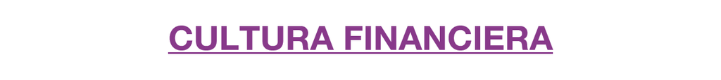

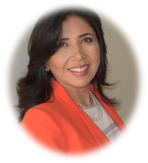

"*Se dice que un individuo promedio durante su vida, realizará al menos 3 compras importantes: la casa, el carro y su plan de pensiones*" **Mariela Méndez Prado, Experta en Finanzas**

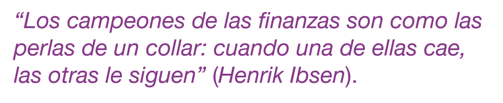

[figure not shown]

## Un poco de historia….

**¿Cómo evaluar el riesgo del crédito?**

- No decisiones subjetivas
- Visión del prestamista
- Visión del prestatario

**Credit scoring se orientaba a:**

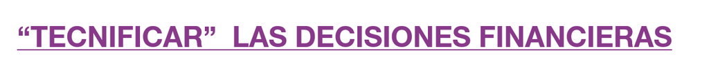

## **Credit Scoring**

Conjunto de modelos de decisión que ayuda a los prestamistas en la concesión del crédito.

Necesitamos contestar preguntas tales como:

- ¿A quién se concede el crédito?
- ¿A qué precio debe conceder el crédito?
- ¿ Qué estrategias operacionales mejorarán la rentabilidad de los prestatarios para los prestamistas?

¡Hora de tomar ésto en serio!

[figure not shown]

## ¿Cómo podemos hacer decisiones financieras robustas?

Entre tantos modelos, lo novedoso son las **Redes Bayesianas**.

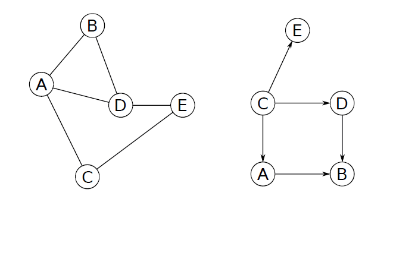

Son modelos gráficos que codifican la probabilidad condicional entre diferentes variables de aprendizaje en un *"gráfico acíclico directo"* (DAG).

[figure not shown]

## Un ejemplo y un vistazo a la probabilidad condicional

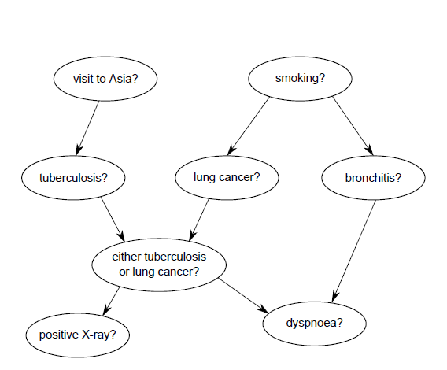

## El problema del crédito alemán

[figure not shown]

## El problema del crédito alemán

"Es peor clasificar a un cliente como BUENO cuando es MALO; que clasificar a un cliente como MALO cuando es BUENO"

[figure not shown]

## **TOMANDO DECISIONES**

¿Se aprueba el crédito o no?

¿Y el riesgo?

## ¿Cómo hacerlo en R?

Set de datos: German credit data

```r
# cdata= read.table("http://archive.ics.uci.edu/
#ml/machine-learning-databases/statlog/german/german.data")
```

- Variable de respuesta: riesgo crediticio
- Número de atributos: 8 numéricos y 13 categóricos

Paquete bnlearn (R Development Core Team 2010)

```r
#install.packages("bnlearn")
#library(bnlearn)
```

## Redes Bayesianas: Modelando el riesgo crediticio

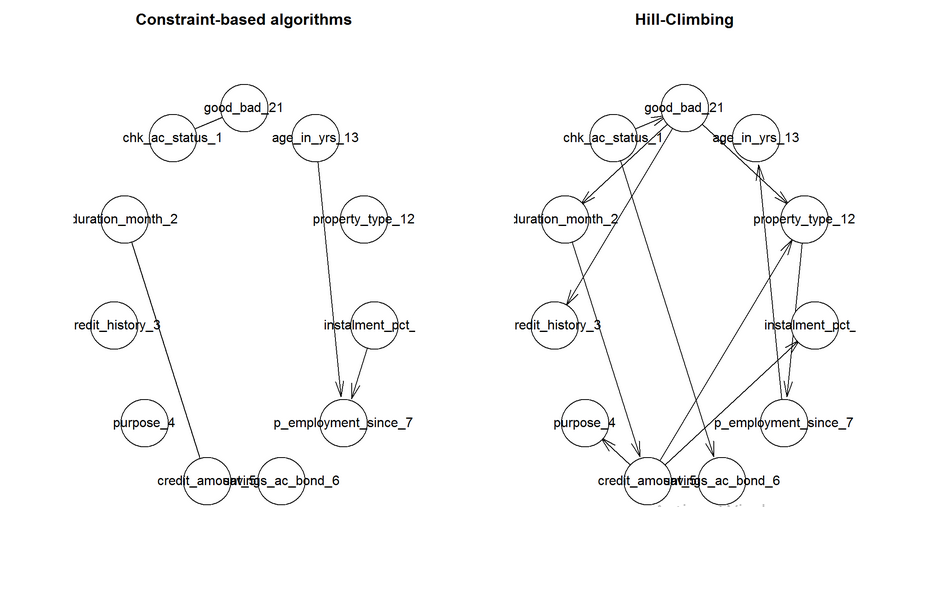

## Redes Bayesianas: Tablas de Probabilidad Condicional

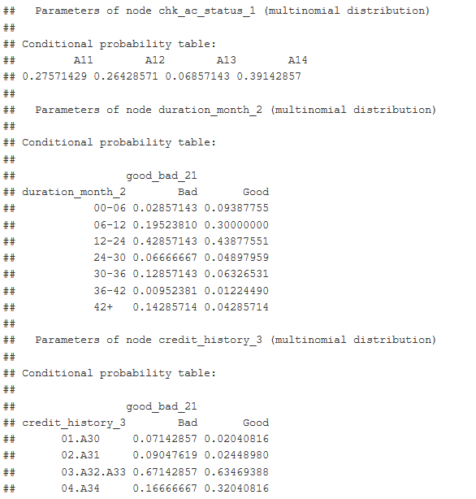

## Redes Bayesianas: Referencias bibliográficas

[figure not shown]

[figure not shown]

Este material ha sido elaborado a partir de los siguientes recursos:

- Thomas L., Edelman D., Crook J. (2001) Credit Scoring and its application. Society for Industrial and Applied Mathematics.
- Scutari M. (2010) Learning Bayesian Network with **bnlearn** R package. Journal of Statistical Software, volume 35, issue 3.
- Scutari M. (2017) Understanding Bayesian Networks with examples in R, University of Oxford, URL: http://www.bnlearn.com/about/slides/slides-ibm16.pdf
- Mondal A. (2016), Classifications in R: Response Modeling/Credit Scoring/Credit Rating using Machine Learning Techniques, rstudio-pubs-static.s3.amazonws.com, URL: https://tinyurl.com/y8k4bdre

[figure not shown]